# assigment week 8

Nora

2026-04-27

```r
suppressPackageStartupMessages({
  library(epiwraps)
  library(ggplot2)
  library(AnnotationHub)
  library(ensembldb)
  library(edgeR)
  library(rtracklayer)
  library(BiocParallel)
  library(bsseq)   # Class and tools to analyze bisulfite sequencing data at CpG-level
  library(DMRcate) # Identification of differentially-methylated regions
  library(dplyr)
})
```

## Part 1

Plot a heatmap of the methylation levels of the genes in top 5 DMR regions (from the practical) located on chr1. You may either do this as we did for promoters during the practical (i.e. using getMeth()), or using signal2Matrix() and plotEnrichedHeatmaps().

### get genes from top 5 DMR regions

```r
# download file with DMR regions
DMR <- readRDS("dmr.rds")

# filter for chromosome 1
DMR_chr1 <- DMR[DMR@seqnames == "chr1"]

# get top 5 DMR (selected based on min_smoothed_fdr)
DMR_top5 <- head(DMR_chr1, 5)
genes_top5_DMR <- DMR_top5$overlapping.genes
genes_top5_DMR <- genes_top5_DMR[!is.na(genes_top5_DMR)]
genes_top5_DMR <- unlist(strsplit(genes_top5_DMR, ",\\s*"))
```

```r
bs <- readRDS("ESC_astrocytes_BSseq.rds")
# remove CpGs that have 0 coverage in some samples:
bs <- bs[rowSums(assay(bs,"Cov")>0)==ncol(bs),]
bs <- BSmooth(bs, BPPARAM=MulticoreParam(2, progress=TRUE))
```

[output not shown]

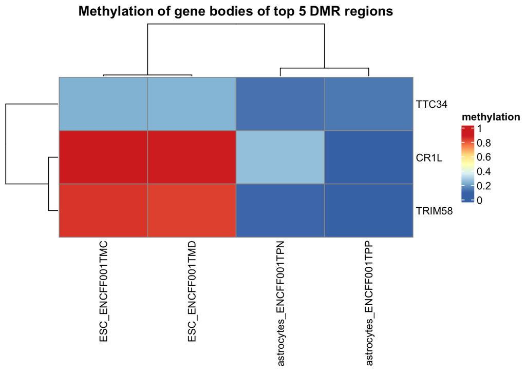

```r
########
genes <- readRDS("hg19_chr1_genes.rds")
myGenes <- genes[genes$symbol %in% genes_top5_DMR]

metgenes <- bsseq::getMeth(bs, regions=myGenes, what="perRegion")
colnames(metgenes) <- colnames(bs)
rownames(metgenes) <- myGenes$symbol
pheatmap(metgenes, name="methylation", main = "Methylation of gene bodies of top 5 DMR regions")
```

```r
# CD46P1 is a pseudogene and therefor not included in the  Granges object "genes"
```

## Part 2

Use the differentially-methylated regions from the practical, and compare those changes to changes in accessibility. For the latter, you can download differential accessibility results from here: https://www.ethz-ins.org/content/ATAC_AstroVsESC_subset.rds Given these two datasets, figure out a way (visualization/analysis) of assessing the extent of agreement (or disagreement) between changes in these two modalities. Describe what you did and what it means in a sentence or two.

### download ATACseq data

```r
download.file("https://www.ethz-ins.org/content/ATAC_AstroVsESC_subset.rds", "ATACseq.gz")
ATACseq <- readRDS("ATACseq.gz")
```

### visualize comparison between DNA methylation and chromatin accessibility

used barplot idea from following paper https://pmc.ncbi.nlm.nih.gov/articles/PMC8897925/#Sec11

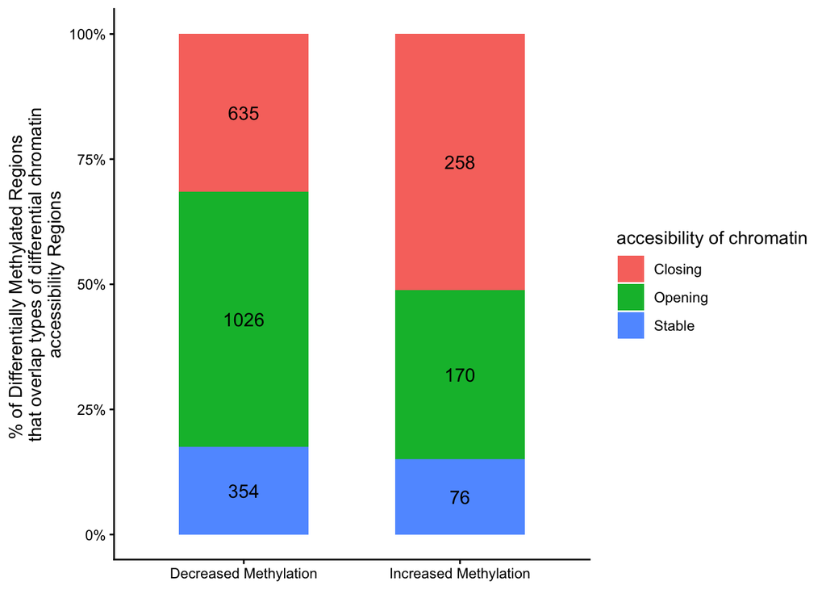

```r
# add column defining if differentially accessibility is opening or closing
mcols(ATACseq)$category <- with(mcols(ATACseq), ifelse(
  FDR < 0.05 & logFC > 0, "Opening",
  ifelse(FDR < 0.05 & logFC < 0, "Closing", "Stable")
))

# add column defining if DMR regions have increased vs decreased methylation
DMR_sign <- DMR[DMR$HMFDR < 0.05]
DMR_sign$direction <- ifelse(DMR_sign$meandiff < 0,
                             "Decreased Methylation",
                             "Increased Methylation")
# find DAR that overlap DMRs & combine results in a dataframe
hits <- findOverlaps(DMR_sign, ATACseq)
df <- data.frame(
  DMR_id = queryHits(hits),
  direction = mcols(DMR_sign)$direction[queryHits(hits)],
  category = mcols(ATACseq)$category[subjectHits(hits)]
)
# if one DMR is overlaped by multiple DARs, select accessibility category that appears the most in that DMR
df_dmr <- df %>%
  group_by(DMR_id, direction) %>%
  summarize(
    category = names(sort(table(category), decreasing = TRUE))[1],
    .groups = "drop"
  )

#make table & add percent
plot_df <- df_dmr %>%
  count(direction, category)
plot_df <- plot_df %>%
  group_by(direction) %>%
  mutate(percent = n / sum(n))

# plot results as barplot
ggplot(plot_df, aes(x = direction, y = percent, fill = category)) +
  geom_bar(stat = "identity", width = 0.6) +

  # counts inside bars
  geom_text(aes(label = n),
            position = position_stack(vjust = 0.5),
            size = 4) +

  scale_y_continuous(labels = scales::percent_format()) +

  labs(
    x = NULL,
    y = "% of Differentially Methylated Regions
    that overlap types of differential chromatin
    accessibility Regions",
    fill = "accesibility of chromatin"
  ) +

  theme_classic() +
  theme(legend.position = "right")
```

The plot shows that in DMR regions with decreased methylation have a higher proportion of opening chromatin/accessible DNA, while DMR with increased methylation show the opposite: more closing chromatin. This relationship is not surprising, however I expected it to be even stronger. Also there’s much more regions with decreased methylation compared to increased methylation